# Medindo a concordância entre o *ranking* e a *expert list*

Autor

Fernando Náufel

Data de Publicação

07/02/2024 20:09

# Apresentação

# *Expert list* como conjunto

Aqui, não existe qualquer ordenação entre os jogadores da *expert list*.

## Exemplo

Considere esta *expert list* com $k = 6$ jogadores (sem ordem):

```
lista = V U G K H F
```

Na forma de tabela:

| jogador | pos |
| --- | --- |
| V | 3,5 |
| U | 3,5 |
| G | 3,5 |
| K | 3,5 |
| H | 3,5 |
| F | 3,5 |

A princípio, como não existe ordem na lista, todos os jogadores estão empatados, o que faria com que todas as posições fossem iguais a

$$\frac{\sum_{i = 1}^{6} i}{6} = 3{,}5000$$

**Atenção**

Mais adiante, vamos precisar rever estas posições, para evitar que o desvio-padrão seja $0$.

Agora, imagine que temos um *ranking* de todos os $n$ jogadores. Considere o menor prefixo do *ranking* que inclui todos os $k = 6$ jogadores da lista (com ordem). Por exemplo:

```
prefixo = I N V M U K G H O F
```

Este prefixo do *ranking* tem tamanho $p = 10$.

Na forma de tabela:

| jogador | pos |
| --- | --- |
| I | 1 |
| N | 2 |
| V | 3 |
| M | 4 |
| U | 5 |
| K | 6 |
| G | 7 |
| H | 8 |
| O | 9 |
| F | 10 |

Para comparar a lista e o prefixo, precisamos que os dois tenham o mesmo tamanho. Vamos adicionar à lista os jogadores que só estão no prefixo, mas estes novos jogadores terão uma posição pior do que os que já estavam na lista e, como a lista não “sabe” nada sobre eles, estes novos jogadores ficarão empatados entre si.

**Atenção**

Lembre-se de que a lista não tem ordem.

O que importa é que os jogadores da lista apareçam no *ranking* (em qualquer ordem!).

Por isso, vamos alterar as posições dos jogadores da lista de acordo com a ordem em que eles aparecem no *ranking*.

Observe que apenas a ordem dos jogadores que já estavam na lista concorda com a ordem deles no *ranking* — não necessariamente as posições.

A nova lista fica

| jogador | pos |
| --- | --- |
| V | 1,0 |
| U | 2,0 |
| K | 3,0 |
| G | 4,0 |
| H | 5,0 |
| F | 6,0 |
| O | 8,5 |
| I | 8,5 |
| M | 8,5 |
| N | 8,5 |

Eis a lista e o *ranking*, agora ambos ordenados:

```
lista   = V U K G H F O I M N
```

```
ranking = I N V M U K G H O F
```

Observe que

- A lista original consistia apenas dos $6$ primeiros jogadores desta nova lista.
- A ordem, no *ranking*, destes $6$ primeiros jogadores da lista está preservada, embora eles possam não aparecer de forma consecutiva no *ranking*.

Agora podemos reunir as informações em uma só tabela:

| jogador | pos_lista | pos_ranking |
| --- | --- | --- |
| V | 1,0 | 3 |
| U | 2,0 | 5 |
| K | 3,0 | 6 |
| G | 4,0 | 7 |
| H | 5,0 | 8 |
| F | 6,0 | 10 |
| O | 8,5 | 9 |
| I | 8,5 | 1 |
| M | 8,5 | 4 |
| N | 8,5 | 2 |

O valor do coeficiente de correlação ordinal de Spearman ($\rho$) para estas duas ordenações é simplesmente igual ao coeficiente de correlação linear de Pearson ($r$) entre elas (já que os valores são posições):

```
ρ = -0,09379581
```

No gráfico abaixo, cada ponto representa um jogador:

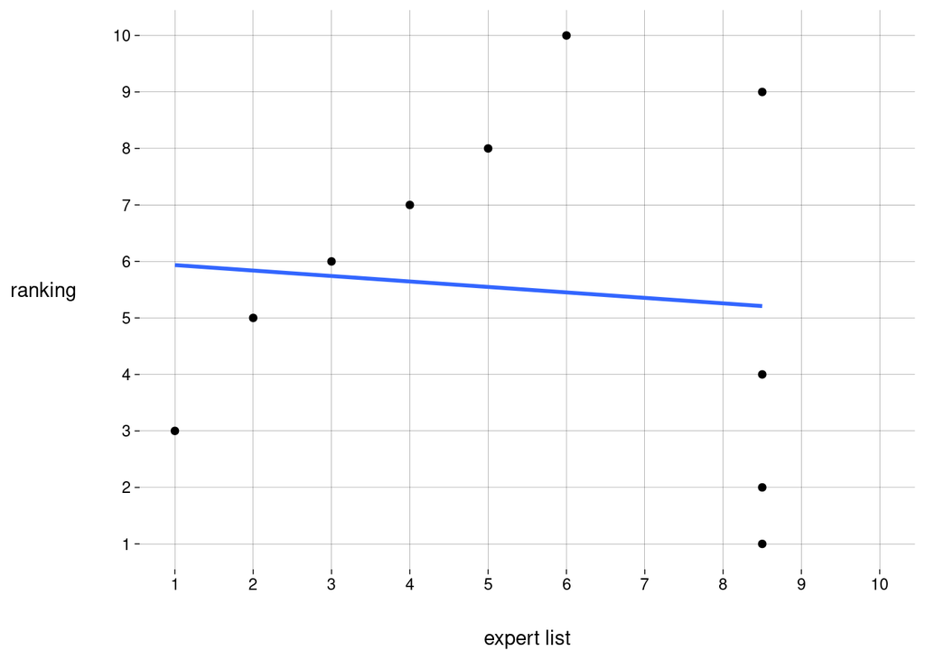

## Casos extremos

### Total concordância

Neste caso, a lista consiste exatamente do top $k$ do *ranking*, e $p = k$:

| jogador | pos_lista | pos_ranking |
| --- | --- | --- |
| D | 1 | 1 |
| A | 2 | 2 |
| V | 3 | 3 |
| G | 4 | 4 |
| H | 5 | 5 |
| C | 6 | 6 |

```
ρ = 1
```

### Total discordância

Teoricamente, o valor mínimo de $\rho$ é $-1$, que acontece quando uma ordanação é o inverso da outra.

Aqui, por causa das observações sobre a não-ordenação da lista, esta situação não pode acontecer.

Os casos desfavoráveis vão acontecer quando o *ranking* contiver, nas primeiras $p - k$ posições, apenas jogadores que não estão na lista:

| jogador | pos_lista | pos_ranking |
| --- | --- | --- |
| D | 1,0 | 5 |
| T | 2,0 | 6 |
| M | 3,0 | 7 |
| A | 4,0 | 8 |
| R | 5,0 | 9 |
| W | 6,0 | 10 |
| B | 8,5 | 1 |
| P | 8,5 | 2 |
| I | 8,5 | 3 |
| X | 8,5 | 4 |

```
ρ = -0,5315096
```

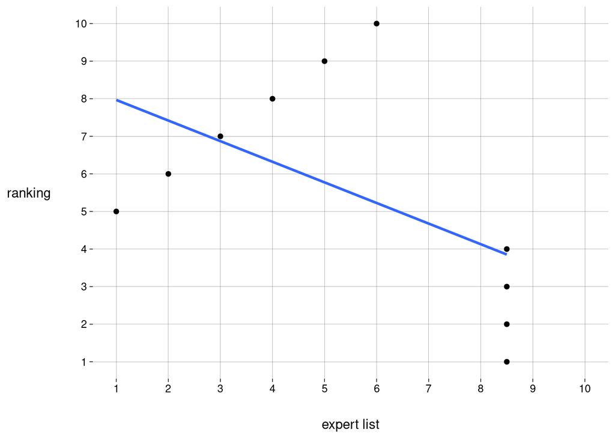

## Casos com mesmo $p$ mas diferentes $\rho$

# *Expert list* como ordem parcial